# Final Project Guide

Andy Atallah

2023-02-02

# Description

I created a personal website using GitHub and a Jekyll theme. I added a theme skin, posts, and a page to the navigation bar. The content in the posts was created using the package calendR, and I will also explain the steps needed to create the calendars shown on the website. I chose this format because I was interested in creating a website and also wanted to showcase a package that may have been too small for a presentation on its own.

# Creating the personal website

I followed the initial steps shown on the [page by Professor Ash](https://lvash.github.io/BIOL1007A/GitHub-website-steps.html), but I made another RStudio project for the purposes of the final assignment. I have a Mac computer, so the steps may not be the same for those with other computers.

### Setting Up

1. Create a GitHub repository called “[your username].github.io”.
2. Create a new R project.
3. Choose “Version Control” > “Git”, paste the URL of your new repository into the first box, and copy the exact name into the second box.
4. Go to the [GitHub page of the “minimal mistakes” Jekyll theme](https://github.com/mmistakes/minimal-mistakes) and click on “Code” > “Download ZIP”.
5. Unzip the folder, click to view the contents, and drag the contents into the folder on your desktop that corresponds to the GitHub repository you created. Mine was a folder called “andya17.github.io”.

### Theme Customization

The website for the Jekyll theme I used has many tips available [here](https://mmistakes.github.io/minimal-mistakes/docs/configuration/).

  ```
  defaults:
  # _pages
  - scope:
      path: ""
      type: pages
    values:
      layout: single
      author_profile: true
  ```

- You can now commit and push the changes using Terminal.

### Checking commits

- You can check whether an edit resulted in any change by going to your repository URL > Settings > Pages > Visit Site.
- Changes may take longer to be finalized than they did for the class assignments, and you can see this on the repository page on GitHub.
  - On the line below the green Code button, changes in progress will show an orange/yellow dot, while a change that went through will show a green check mark.
  - If an error occurs, you will see a red X mark. GitHub might also send an email if you have it enabled. To get a sense of what went wrong, you can click on the X and check the “Details”. GitHub will show a long stretch of code which may contain an error message including which line in which file produced the error. This is helpful if you made multiple changes, like you might have for the _config.yml file.

### Creating posts

1. You may see that there is [a page on the theme guide](https://mmistakes.github.io/minimal-mistakes/docs/posts/) about posts. You should first create a folder called “_posts” (without the quotation marks) and place it within your repository folder. This may be confusing if you haven’t deleted the docs folder, since that folder already has a folder called _posts inside. I would recommend deleting the docs folder and working outside of it for creating posts.
2. Posts and pages use a different markdown language than R Markdown. I use a Mac and found it easiest to follow the recommendation to download the free version of [BBEdit](https://www.barebones.com/products/bbedit/download.html) so that I could save files with the “.md” extension.
3. In BBEdit, I set the front matter of the first post file. Similar to R Markdown, .md files need text formatted in a certain way before any content. It can be as simple as the following, since the very bottom section of _config.yml (# Defaults) should have had a section specifying the default layout of the page for all posts.

```
---
title:  "[your title]"
date:   2023-02-01
---
```

4. For the posts I added, I used what the theme guide [calls a Jekyll Helper](https://mmistakes.github.io/minimal-mistakes/docs/helpers/). The formatting is found below the text “Using the figure include like so:”.
- I added a picture of the content I wanted to show in the post as a .png file to the “assets” folder.
- In the post, I used the Jekyll Helper to add a picture in-line with a caption.
- I referred to the path of the image by putting /assets/ before the file name, and I also used the formatting which is present on the theme guide under “Figure”. This allowed a picture to be inserted in-line with a caption underneath.
5. Post files are titled in a certain way, with a YYYY-MM-DD format before a title. My first title was “2023-02-01-february-calendar.md”. They are then placed into the _posts folder you created.

### Creating a page

1. You will need to create a folder in your repository folder called “_pages” (without the quotation marks).
2. Pages require the addition of a “permalink” to the front matter. You should add the path of what you want the URL of the page to be.

```
---
title:  "Tree Photos"
permalink: /treephotos/
author_profile: true
comments: true
---
```

3. You should then click on the “_data” folder and open “navigation.yml”. Inside, you need to create a new title/URL set with the same URL as the path you put in the page front matter. I left in some of the commented title/URL sets that the file came with, but you can see that the title “Tree Photos” and the URL /treephotos/ are uncommented.

```
# main links
main:
  # - title: "Quick-Start Guide"
  #  url: https://mmistakes.github.io/minimal-mistakes/docs/quick-start-guide/
  # - title: "About"
  #   url: https://mmistakes.github.io/minimal-mistakes/about/
   - title: "Tree Photos"
     url: /treephotos/
```

4. For my page, I used the same method of adding pictures with captions as I did for posts. I added line breaks by adding several spaces after a phrase and then pressing return. I was able to do this within the formatting of the [Jekyll Helper](https://mmistakes.github.io/minimal-mistakes/docs/helpers/) (Under the phrase “Using the figure include like so:”).
5. Pages you add in this way should show up on the navigation bar on the top of your website.

# Using the calendR package

```r
# Load the library.
library(calendR)
```

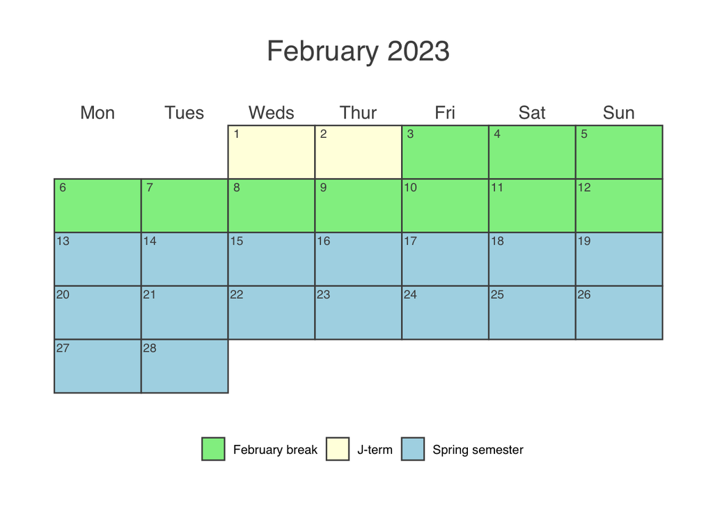

```r
# I want to make a calendar for February 2023, so I create a vector with one NA value for each day.
datesFeb <- rep(NA, 28)
# Values 1 and 2 of the vector will be "J-term".
datesFeb[c(1:2)] <- "J-term"
# Values 3 to 12 of the vector will be "February break".
datesFeb[c(3:12)] <- "February break"
datesFeb[c(13:28)] <- "Spring semester"

# Create a variable and assign the calendR function.
february23 <- calendR(
                    year=2023, #S tart with the year.
                    month=2, # Add the month for a monthly calendar.
                    title="February 2023", # Add a title to be displayed above the graph.
                    weeknames=c("Mon", "Tues", "Weds", "Thur", "Fri", "Sat", "Sun"), # Add whatever abbreviations for the names of days that you wish.
                    start="M", # This starts the week on Monday on the calendar. Make sure you put Monday (or Mon, or M) first in the weeknames vector if you do this.
                    lty=1, # This adds lines between each day.
                    special.days=datesFeb, # Special days can be assigned different colors. Refer back to the 28-day vector created for February above.
                    special.col=c("lightgreen", "lightyellow", "lightblue"), # I have a vector in which I have assigned three different periods - J-term, February break, and Spring semester. I therefore need to specify three colors using c(). The order of the colors will affect the periods of time alphabetically -- lightgreen is applied to the days of February 2023 to which I assigned the word "February break" because it is alphabetically first out of the three.
                    legend.pos="bottom") # This will create a legend for the three periods of February that I assigned different colors.

print(february23)
```

For the 2023 full year academic calendar, I used a similar method as the first calendar. Installing the lubridate package may assist with yearly calendars, for you need to specify the day of the year for a vector; previously, we just used the day of the month of February.

```r
library(calendR)
library(lubridate)

yday("2023-02-02") # yday() is a lubridate function. This helped me to know what day of the year corresponded to a specific date. I used the output values to help with assigning periods of the year below.
```

```
## [1] 33
```

```r
yday("2023-02-13")
```

```
## [1] 44
```

```r
yday("2023-03-17")
```

```
## [1] 76
```

```r
yday("2023-03-27")
```

```
## [1] 86
```

```r
yday("2023-05-19")
```

```
## [1] 139
```

```r
yday("2023-09-11")
```

```
## [1] 254
```

```r
yday("2023-12-15")
```

```
## [1] 349
```

```r
academicDates <- rep(NA, 365) # There should be 365 possible spaces for special days, since we are dealing with the whole year.
academicDates[c(1:4, 350:365)] <- "Winter break" # Winter break includes days at the start and end of the year, which we can include like this.
academicDates[c(5:33)] <- "J-term"
academicDates[c(34:43)] <- "February break"
academicDates[c(44:76, 86:139)] <- "Spring semester"
academicDates[c(77:85)] <- "Spring break"
academicDates[c(140:253)] <- "Summer"
academicDates[c(254:349)] <- "Fall semester"

academicYear <- calendR(
        year=2023, # Use the year argument without a month argument, since this will be a yearly calendar.
        start="S", # Start on Sunday.
        special.days=academicDates, # Add the variable created above.
        special.col = c("orange", "lightblue", "deepskyblue", "lightgreen", "darkseagreen1", "lightyellow", "gainsboro"), # Counting the distinct names which we applied to academicDates, I have seven. I therefore need to specify seven colors. This will go in alphabetical order, so I thought of which would come first (Fall semester).
        legend.pos = "top", # Add the legend to the top of the output image.
        pdf = TRUE, # You can also create a PDF directly in your repository folder.
        orientation="portrait", # Format the output so that it is taller.
        doc_name = "final-calendR-pdf") # This will be the name of the PDF that shows up in the folder. You can't use the same name if you've already knitted before and a PDF was created. This can be cumbersome if you knit many times, so make sure to change the filename.

# This does not show up well when knitting. Check the PDF for a much better view of the calendar!
```

[output not shown]